# Basic inferential data analysis. The Effect of Vitamin C on Tooth Growth in Guinea Pigs.

# Data overview

The response is the length of odontoblasts (teeth) in each of 10 guinea pigs at each of three dose levels of Vitamin C (0.5, 1, and 2 mg) with each of two delivery methods (orange juice or ascorbic acid). A data frame with 60 observations on 3 variables: len(Tooth length), supp(Supplement type (VC or OJ)), dose(Dose in milligrams).

```r
data(ToothGrowth)
d <- ToothGrowth
```

# 1. Summary of the data

```r
summary(d)
```

```
##       len        supp         dose
##  Min.   : 4.20   OJ:30   Min.   :0.500
##  1st Qu.:13.07   VC:30   1st Qu.:0.500
##  Median :19.25           Median :1.000
##  Mean   :18.81           Mean   :1.167
##  3rd Qu.:25.27           3rd Qu.:2.000
##  Max.   :33.90           Max.   :2.000
```

We can point out some data properties:

| Property | Observations |
| --- | --- |
| Supplementary | 50% (30 observations) is Orange Juice supplementary |
|  | 50% (30 observations) is ascorbic acid supplementary |
| Dose | Mean of doze of a supplementary is 1.167 mg |
|  | Max doze of a supplementary is 2.000 mg |
|  | Min doze of a supplementary is 0.500 mg |
| Tooth Length | Mean of tooth length is 18.81 cm |
|  | Max tooth length is 33.90 cm |
|  | Min tooth length is 4.20 cm |

The following graph is a histogram of the tooth length:

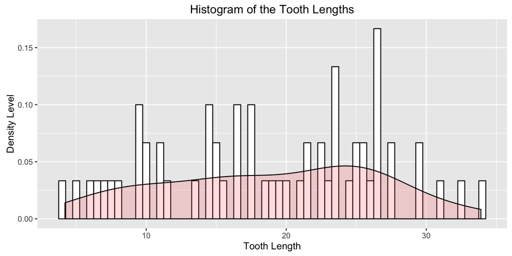

We can say the data is slightly normalized. As the shape is more looks like Gaussian.

The following graph shows the comparison of the tooth length by supplementary type:

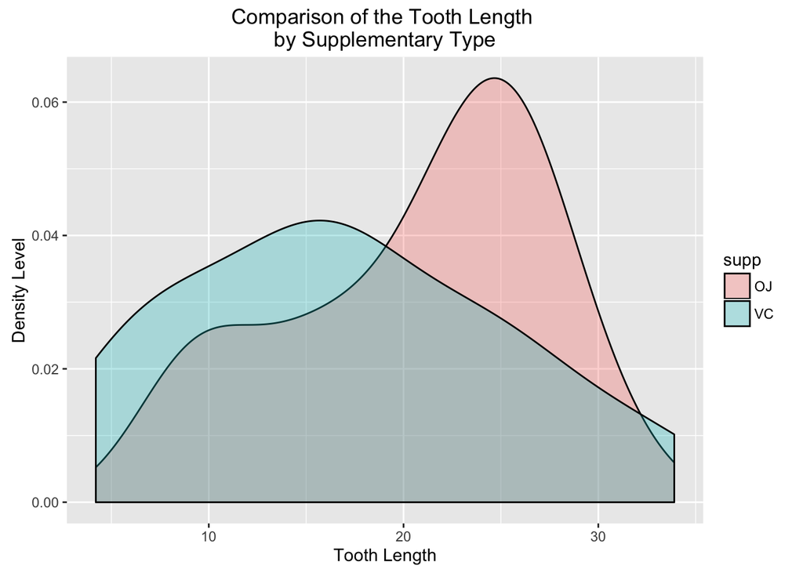

```r
  oj_mean <- mean(d[which(d$supp=="OJ"),][,1])
  vc_mean <- mean(d[which(d$supp=="VC"),][,1])
  c(oj_mean, vc_mean)
```

```
## [1] 20.66333 16.96333
```

We can see that OJ has better results as the tooth length mean for this supplementary has more value than VC with the same observation count and dose amounts.

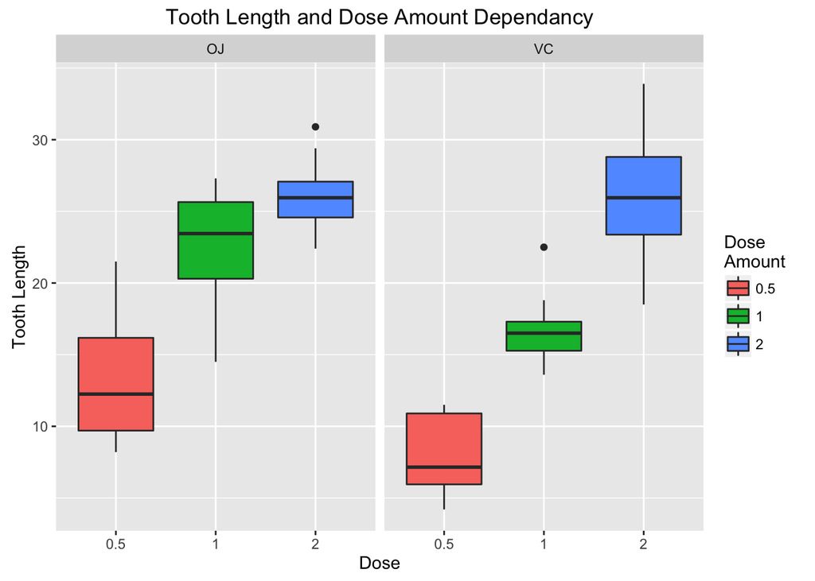

This graph shows that tooth length depends on the dose amount.